# Project_5-Prediction_of_Drinking_Water_Potability

Tiffany & Fahad

11/09/2021

#The goals of the project includes the following: 1. Perform exploratory data analysis 2. Predict the outcome variable with some form of regression 3. Exploratory data analysis may involve the following 4.Perform univariate distribution analysis for as many variables as possible, confirmed by quantitative metrics that describe the plots 5. Plot grouped density and grouped histogram, to visualize frequency distribution of outcome variables and other variables in the dataset 6. Plot grouped categorical plots to visualize patterns that may exist in any relationships within the dataset. 7. Conduct bias analysis with a demographic variable if necessary. 8. Build correlation matrix to confirm the magnitude of the correlation coefficient and direction of observed relationships 9. Use the observed correlation relationships to perform some form of regression to predict the outcome variable in one of the following ways. linear regression 10. Logistic regression: Forced entry, Hierarchical, Stepwise ( slide 19 week 11 bias and logistic regression )

# Project #5: Drinking Water Potability

## Description:

Context Access to safe drinking water is essential to health, a basic human right, and a component of effective policy for health protection. This is important as a health and development issue at a national, regional, and local level. In some regions, it has been shown that investments in water supply and sanitation can yield a net economic benefit, since the reductions in adverse health effects and health care costs outweigh the costs of undertaking the interventions.

## Null Hypothesis:

There is no relationship between optimal levels of chemical components contained in treated water and portability of consumed water.

## Alternative Hypothesis:

Two or more optimal levels of combined features are cause for making the water not potable.

See if you can find any other trends in the data to predict portability of consumed water or find any clear indications of relationships between the predictors.

## Content:

The drinkingwaterpotability.csv file contains water quality metrics for 3276 different water bodies. 1. **pH value**: PH is an important parameter in evaluating the acid-base balance of water. It is also the indicator of the acidic or alkaline condition of water status. WHO has recommended the maximum permissible limit of pH from 6.5 to 8.5. The current investigation ranges were 6.52–6.83 which are in the range of WHO standards. 2. **Hardness**: Hardness is mainly caused by calcium and magnesium salts. These salts are dissolved from geologic deposits through which water travels. The length of time water is in contact with hardness-producing material helps determine how much hardness there is in raw water. Hardness was originally defined as the capacity of water to precipitate soap caused by Calcium and Magnesium. 3. **Solids** (Total dissolved solids - TDS): Water has the ability to dissolve a wide range of inorganic and some organic minerals or salts such as potassium, calcium, sodium, bicarbonates, chlorides, magnesium, sulfates, etc. These minerals produced an unwanted taste and diluted color in the appearance of water. This is the important parameter for the use of water. The water with a high TDS value indicates that water is highly mineralized. The desirable limit for TDS is 500 mg/l and the maximum limit is 1000 mg/l which is prescribed for drinking purposes. 4. **Chloramines**: Chlorine and chloramine are the major disinfectants used in public water systems. Chloramines are most commonly formed when ammonia is added to chlorine to treat drinking water. Chlorine levels up to 4 milligrams per liter (mg/L or 4 parts per million (ppm)) are considered safe in drinking water. 5. **Sulfate**: Sulfates are naturally occurring substances that are found in minerals, soil, and rocks. They are present in ambient air, groundwater, plants, and food. The principal commercial use of sulfate is in the chemical industry. Sulfate concentration in seawater is about 2,700 milligrams per liter (mg/L). It ranges from 3 to 30 mg/L in most freshwater supplies, although much higher concentrations (1000 mg/L) are found in some geographic locations. 6. **Conductivity**: Pure water is not a good conductor of electric current rather’s a good insulator. An increase in ions concentration enhances the electrical conductivity of water. Generally, the amount of dissolved solids in water determines electrical conductivity. Electrical conductivity (EC) actually measures the ionic process of a solution that enables it to transmit current. According to WHO standards, EC value should not exceed 400 μS/cm. 7. **Organic_carbon**: Total Organic Carbon (TOC) in source waters comes from decaying natural organic matter (NOM) as well as synthetic sources. TOC is a measure of the total amount of carbon in organic compounds in pure water. According to US EPA < 2 mg/L as TOC in treated / drinking water, and < 4 mg/Lit in source water which is use for treatment. 8. **Trihalomethanes**: THMs are chemicals that may be found in water treated with chlorine. The concentration of THMs in drinking water varies according to the level of organic material in the water, the amount of chlorine required to treat the water, and the temperature of the water that is being treated. THM levels up to 80 ppm are considered safe in drinking water. 9. **Turbidity**: The turbidity of water depends on the quantity of solid matter present in the suspended state. It is a measure of the light-emitting properties of water and the test is used to indicate the quality of waste discharge with respect to the colloidal matter. The mean turbidity value obtained for Wondo Genet Campus (0.98 NTU) is lower than the WHO recommended value of 5.00 NTU. 10. **Potability**: Indicates if water is safe for human consumption where 1 means Potable and 0 means Not potable.

Read dataset and other assets remotely from AWS-S3

```r
#AWS environment setup which is not secured but we have it for temporary usage to access AWS resources
# Sys.setenv(
#   AWS_ACCESS_KEY_ID = "AKIA4CSJQNSCJA74HAIJ",
#   AWS_SECRET_ACCESS_KEY = "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",
#   AWS_REGION = "us-east-1")
```

```r
# Connecting to RPostgreSQL
# drv <- dbDriver('PostgreSQL')
# db <- 'db-instance-hs631'
# host_db <- 'db-instance-hs631.cllvlwixyq2w.us-east-1.rds.amazonaws.com'
# db_port <- '5432'
# db_user <- 'postgres'
# db_password <- 'postgresDB2021'
# Will continou working on the integration later as not required by the project
# conn <- dbConnect(drv, dbname=db, host=host_db, port=db_port, user=db_user, password=db_password)
#
# # Connecting to RPostgres
# # with the same connection variables without 'drv'
#
# conn <- dbConnect(RPostgres::Postgres(), dbname = db2, host=host_db, port=db_port, user=db_user, password=db_password)
#
```

Read dataset from local machine:

```r
#Read dataset from Github
x <- getURL("https://raw.githubusercontent.com/nitieaj/Project_5-Prediction_of_Drinking_Water_Portability/main/data/drinking_water_potability.csv")
dw.potability <- read.csv(text = x)
#dw.potability <- read.csv("./Data/drinking_water_potability.csv", header = TRUE, sep = ",")%>% glimpse()#using glimpse to have a quick look t the variables we have and the dimensions of the dataset
```

We have about 3,275 * 10 dimension dataset

```r
str(dw.potability)
```

```
'data.frame':   3276 obs. of  10 variables:
 $ ph             : num  4.68 3.72 8.1 8.32 9.09 ...
 $ Hardness       : num  205 129 224 214 181 ...
 $ Solids         : num  20791 18630 19910 22018 17979 ...
 $ Chloramines    : num  7.3 6.64 9.28 8.06 6.55 ...
 $ Sulfate        : num  369 NA NA 357 310 ...
 $ Conductivity   : num  564 593 419 363 398 ...
 $ Organic_carbon : num  10.4 15.2 16.9 18.4 11.6 ...
 $ Trihalomethanes: num  87 56.3 66.4 100.3 32 ...
 $ Turbidity      : num  2.96 4.5 3.06 4.63 4.08 ...
 $ Potability     : int  0 0 0 0 0 0 0 0 0 0 ...
```

```r
library(janitor) #using janitor library to use clean_names function to:
                    #Returns names with only lowercase letters, with _ as a separator
                    #Handles special characters and spaces
                    #Appends numbers to duplicated names
                    #Converts “%” to “percent” to retain meaning

dw.potability <- dw.potability %>%
  mutate(Potability = as.numeric(Potability)) %>% #convert Int to factor in *Potability* feature
  clean_names() %>% glimpse()
```

```
Rows: 3,276
Columns: 10
$ ph              <dbl> 4.678920, 3.716080, 8.099124, 8.316766, 9.092223, 5.584087, 10.…
$ hardness        <dbl> 204.8905, 129.4229, 224.2363, 214.3734, 181.1015, 188.3133, 248…
$ solids          <dbl> 20791.32, 18630.06, 19909.54, 22018.42, 17978.99, 28748.69, 287…
$ chloramines     <dbl> 7.300212, 6.635246, 9.275884, 8.059332, 6.546600, 7.544869, 7.5…
$ sulfate         <dbl> 368.5164, NA, NA, 356.8861, 310.1357, 326.6784, 393.6634, 303.3…
$ conductivity    <dbl> 564.3087, 592.8854, 418.6062, 363.2665, 398.4108, 280.4679, 283…
$ organic_carbon  <dbl> 10.379783, 15.180013, 16.868637, 18.436525, 11.558279, 8.399735…
$ trihalomethanes <dbl> 86.99097, 56.32908, 66.42009, 100.34167, 31.99799, 54.91786, 84…
$ turbidity       <dbl> 2.963135, 4.500656, 3.055934, 4.628771, 4.075075, 2.559708, 2.6…
$ potability      <dbl> 0, 0, 0, 0, 0, 0, 0, 0, 0, 0, 0, 0, 0, 0, 0, 0, 0, 0, 0, 0, 0, …
```

#Now, our variables are in lower case which is intutive whhile we’re coding

```r
summary(dw.potability)
```

```
       ph            hardness          solids         chloramines        sulfate
 Min.   : 0.000   Min.   : 47.43   Min.   :  320.9   Min.   : 0.352   Min.   :129.0
 1st Qu.: 6.092   1st Qu.:176.85   1st Qu.:15666.7   1st Qu.: 6.127   1st Qu.:307.7
 Median : 7.036   Median :196.97   Median :20927.8   Median : 7.130   Median :333.1
 Mean   : 7.080   Mean   :196.37   Mean   :22014.1   Mean   : 7.122   Mean   :333.6
 3rd Qu.: 8.062   3rd Qu.:216.67   3rd Qu.:27332.8   3rd Qu.: 8.115   3rd Qu.:359.7
 Max.   :14.000   Max.   :323.12   Max.   :61227.2   Max.   :13.127   Max.   :481.0
 NA's   :490                                                          NA's   :743
  conductivity   organic_carbon  trihalomethanes     turbidity       potability
 Min.   :181.5   Min.   : 2.20   Min.   :  0.738   Min.   :1.450   Min.   :0.0000
 1st Qu.:365.7   1st Qu.:12.07   1st Qu.: 55.845   1st Qu.:3.440   1st Qu.:0.0000
 Median :421.9   Median :14.22   Median : 66.622   Median :3.955   Median :0.0000
 Mean   :426.2   Mean   :14.28   Mean   : 66.396   Mean   :3.967   Mean   :0.3901
 3rd Qu.:481.8   3rd Qu.:16.56   3rd Qu.: 77.337   3rd Qu.:4.500   3rd Qu.:1.0000
 Max.   :753.3   Max.   :28.30   Max.   :124.000   Max.   :6.739   Max.   :1.0000
                                 NA's   :162
```

```r
dw.potability %>%
  summarise_all(~ sum(is.na(.)))
```

| ph | hardness | solids | chloramines | sulfate | conductivity | organic_carbon | trihalomethanes | turbidity | potability |
| --- | --- | --- | --- | --- | --- | --- | --- | --- | --- |
| 490 | 0 | 0 | 0 | 743 | 0 | 0 | 162 | 0 | 0 |

#We have three features are missing values and they are orded bellow by the highest NA values:

**sulfate** = 743 missing values **ph** = 490 missing values **trihalomethanes** = 162 missing values

```r
str(completed.df)
```

```
'data.frame':   2045 obs. of  10 variables:
 $ ph             : num  4.68 8.32 9.09 5.58 10.22 ...
 $ hardness       : num  205 214 181 188 248 ...
 $ solids         : num  20791 22018 17979 28749 28750 ...
 $ chloramines    : num  7.3 8.06 6.55 7.54 7.51 ...
 $ sulfate        : num  369 357 310 327 394 ...
 $ conductivity   : num  564 363 398 280 284 ...
 $ organic_carbon : num  10.4 18.4 11.6 8.4 13.8 ...
 $ trihalomethanes: num  87 100.3 32 54.9 84.6 ...
 $ turbidity      : num  2.96 4.63 4.08 2.56 2.67 ...
 $ potability     : num  0 0 0 0 0 0 0 0 0 0 ...
```

```r
#Calling the required libraries for this chunk
#library(ggplot2) # For vizulization computation
#library(skimr)#which is similar to summary function, but with opinionated in its defaults
#library(scales)# to converting from data values to perceptual properties
#library(forcats)#to handle categorical variables, variables that have a fixed and known set of possible values. Factors are also helpful for reordering character vectors to improve display


#creating a new variables that filter our dataset by using skim function and show the output as table
skim.dw.pot <- dw.potability %>%  skim() %>%
   filter(n_missing != 0) %>%
   as_tibble() %>%
   mutate(n_missing, skim_variable, complete_rate) %>% #Mutate targeted variables produced by Skim function such as skim_variable, n_missing, complete_rate  to help us with missing rate classification
   mutate(missing_rate = round(abs(complete_rate - 1) * 100, 1)) # by subtracting 1r from the complete_rate feature and times that by 100


skim.dw.pot
```

| skim_type | skim_variable | n_missing | complete_rate | numeric.mean | numeric.sd | numeric.p0 | numeric.p25 | numeric.p50 | numeric.p75 | numeric.p100 | numeric.hist | missing_rate |
| --- | --- | --- | --- | --- | --- | --- | --- | --- | --- | --- | --- | --- |
| numeric | ph | 490 | 0.8504274 | 7.079932 | 1.594683 | 0.000 | 6.09181 | 7.035894 | 8.061702 | 14.0000 | ▁▂▇▂▁ | 15.0 |
| numeric | sulfate | 743 | 0.7731990 | 333.645373 | 41.232952 | 129.000 | 307.70447 | 333.052491 | 359.665835 | 481.0306 | ▁▁▇▆▁ | 22.7 |
| numeric | trihalomethanes | 162 | 0.9505495 | 66.396293 | 16.175008 | 0.738 | 55.84454 | 66.622485 | 77.337473 | 124.0000 | ▁▂▇▅▁ | 4.9 |

We will visulize the **skim_variable**, **n_missing, mean** as a missing value rate aganist the atrgeted features **sulfate**, **ph**, **trihalomethanes**

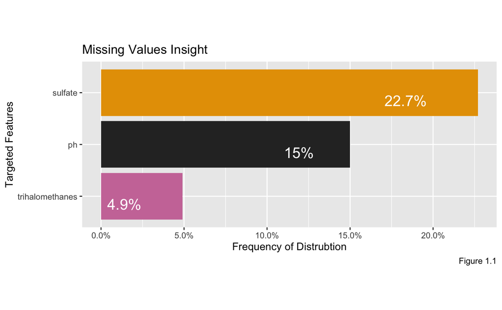

```r
skim.dw.pot %>%
  ggplot(aes(
     x = fct_reorder(skim_variable, n_missing, mean),
     y = missing_rate,
     fill = skim_variable, #we fill skim_variable and n_missing, and
     label = paste0(missing_rate, "%")
   )) +
   geom_col(width = .9) +
   geom_text(
     size = 5.5,
     hjust = 2.2,
     vjust = 1.25,
     col = "white"
   ) +
   coord_flip() + theme(aspect.ratio = .4) +
   theme(
     legend.position = "none"
   ) +
   scale_y_continuous(label = label_percent(scale = 1)) +
   scale_fill_manual(values = c("#2D2D2D",
                                "#E69F00",
                                "#CC79A7")) +
   labs(title = "Missing Values Insight", x = "Targeted Features", y = "Frequency of Distrubtion", caption = "Figure 1.1")
```

**sulfate** = 743 missing values ~ 22.7% **ph** = 490 missing values ~ 15% **trihalomethanes** = 162 missing values ~ 4.9%

```r
dw.potability %>%
  dplyr::select(potability) %>%
  count(potability) %>%
  mutate(percent = paste0(round(n / sum(n) * 100), "%"), 2) %>%
  ggplot(aes(
    x = potability,
    y = n,
    label = percent,
    fill = potability
  )) +
  geom_col() +
  geom_text(vjust = - 0.3, color = "#7C4EA8") +
  scale_fill_manual(values = c("#D55E00", "#0072B2")) +
  labs(
    title = "Distribution of the Potable Water",
    x = "Potability Class 0 and 1",
    y = "Distribution Frequency",
    caption = "Figure 1.2"
  )
```

[output not shown]

```
Error: Continuous value supplied to discrete scale
```

Before we process the function, we need to know the total number of of NA value in the entire dataset

```r
#create a new vector to Impute the missing values with the mean which is a naive solution to make this missing values filled
#Imputation method 1: mean
mean.df <- dw.potability %>%
  group_by(potability) %>%
  mutate(across(where(is.numeric), ~if_else(is.na(.), mean(., na.rm = T), as.numeric(.)))) %>%
  ungroup()

head(mean.df)
```

| ph | hardness | solids | chloramines | sulfate | conductivity | organic_carbon | trihalomethanes | turbidity | potability |
| --- | --- | --- | --- | --- | --- | --- | --- | --- | --- |
| 4.678920 | 204.8905 | 20791.32 | 7.300212 | 368.5164 | 564.3087 | 10.379783 | 86.99097 | 2.963135 | 0 |
| 3.716080 | 129.4229 | 18630.06 | 6.635246 | 334.5643 | 592.8854 | 15.180013 | 56.32908 | 4.500656 | 0 |
| 8.099124 | 224.2363 | 19909.54 | 9.275884 | 334.5643 | 418.6062 | 16.868637 | 66.42009 | 3.055934 | 0 |
| 8.316766 | 214.3734 | 22018.42 | 8.059332 | 356.8861 | 363.2665 | 18.436525 | 100.34167 | 4.628771 | 0 |
| 9.092223 | 181.1015 | 17978.99 | 6.546600 | 310.1357 | 398.4108 | 11.558279 | 31.99799 | 4.075075 | 0 |
| 5.584087 | 188.3133 | 28748.69 | 7.544869 | 326.6784 | 280.4679 | 8.399735 | 54.91786 | 2.559708 | 0 |

```r
#mean.df
```

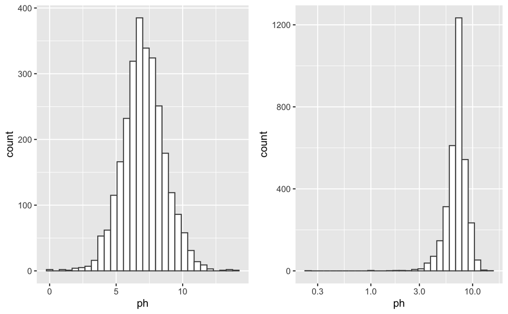

```r
#Comparing the dataset with NA values and with mean Imputed NA
p1 <- ggplot(dw.potability, aes(ph)) +
        geom_histogram(fill = "white", color = "grey30")

p2 <- ggplot(mean.df, aes(ph)) +
        geom_histogram(fill = "white", color = "grey30") +
        scale_x_log10()

grid.arrange(p1, p2, ncol = 2)
```